# Spatial Data Workshop

2023 EPA R User Group Workshop

Marc Weber

EPA (USA)

Michael Dumelle

EPA (USA)

2023-10-18

## Who Are We?

Marc Weber is a geographer at the Pacific Ecological Systems Division (PESD) at the United States Environmental Protection Agency (USEPA). His work supports various aspects of the USEPA’s National Aquatic Resource Surveys (NARS), which characterize the condition of waters across the United States, as he helped develop and maintains the StreamCat and LakeCat datasets. His work focuses on spatial analysis in R and Python, Geographic Information Science (GIS), aquatic ecology, remote sensing, open source science and environmental modeling.

## Who Are We?

Michael Dumelle is a statistician for the United States Environmental Protection Agency (USEPA). He works primarily on facilitating the survey design and analysis of USEPA’s National Aquatic Resource Surveys (NARS), which characterize the condition of waters across the United States. His primary research interests are in spatial statistics, survey design, environmental and ecological applications, and software development.

## Disclaimer

The views expressed in this workshop are those of the authors and do not necessarily represent the views or policies of the U.S. Environmental Protection Agency or the U.S. National Oceanic and Atmospheric Administration. Any mention of trade names, products, or services does not imply an endorsement by the U.S. government, the U.S. Environmental Protection Agency, or the U.S. National Oceanic and Atmospheric Administration. The U.S. Environmental Protection Agency and the U.S. National Oceanic and Atmospheric Administration do not endorse any commercial products, services, or enterprises.

## What Will We Cover?

- Foundations of spatial data
- Visualizing spatial data
- Geoprocessing spatial data
- Advanced applications
- Focus on the **R** computing language

# Foundations

## Goals

1. Understand fundamental spatial data structures and libraries in **R**.
2. Become familiar with coordinate reference systems.
3. Geographic I/O (input/output).

## Data Structures

- Review data structures section in workbook
- Cover vectors, matrices, arrays, lists, data frames, etc.
- Cover data frame manipulation using [tidyverse](https://www.tidyverse.org/) functions and the pipe operator (`%>%` or `|>`)

## Why R for Spatial Data Analysis?

- Lightweight, open-source, and cross-platform
- Provides tools for automation and reproducibility
- Seamlessly integrates spatial data analysis and statistical analysis in one environment
- Handles vector and raster data

## R Drawbacks for GIS Work

- R is less interactive than desktop applications like ArcGIS or QGIS
- Handling coordinate reference systems is more challenging
- In-memory analysis can be prohibitive for large data
- Steep learning curve

## A Motivating Example

- Simple, expressive code

```r
library(tmap)
library(tmaptools)
library(dplyr)

# find my town!
my_town <- tmaptools::geocode_OSM("Corvallis OR USA", as.sf = TRUE)
glimpse(my_town)
```

```
Rows: 1
Columns: 9
$ query   <chr> "Corvallis OR USA"
$ lat     <dbl> 44.56457
$ lon     <dbl> -123.262
$ lat_min <dbl> 44.51993
$ lat_max <dbl> 44.60724
$ lon_min <dbl> -123.3362
$ lon_max <dbl> -123.231
$ bbox    <POLYGON [°]> POLYGON ((-123.3362 44.5199...
$ point   <POINT [°]> POINT (-123.262 44.56457)
```

## Your Turn

`05:00`

## A Choropleth Map

- A choropleth map is a map that connects statistical summaries to geographic characteristics
- The `tigris` package can retrieve census, county, and state boundaries as vector `sf` data

```r
library(tigris)
library(sf)
counties <- counties("Oregon", cb = TRUE)
counties$area <- as.numeric(st_area(counties))
glimpse(counties)

tm_shape(counties) +
  tm_polygons("area", style="quantile", title="Area of Oregon Counties")
```

## A Choropleth Map

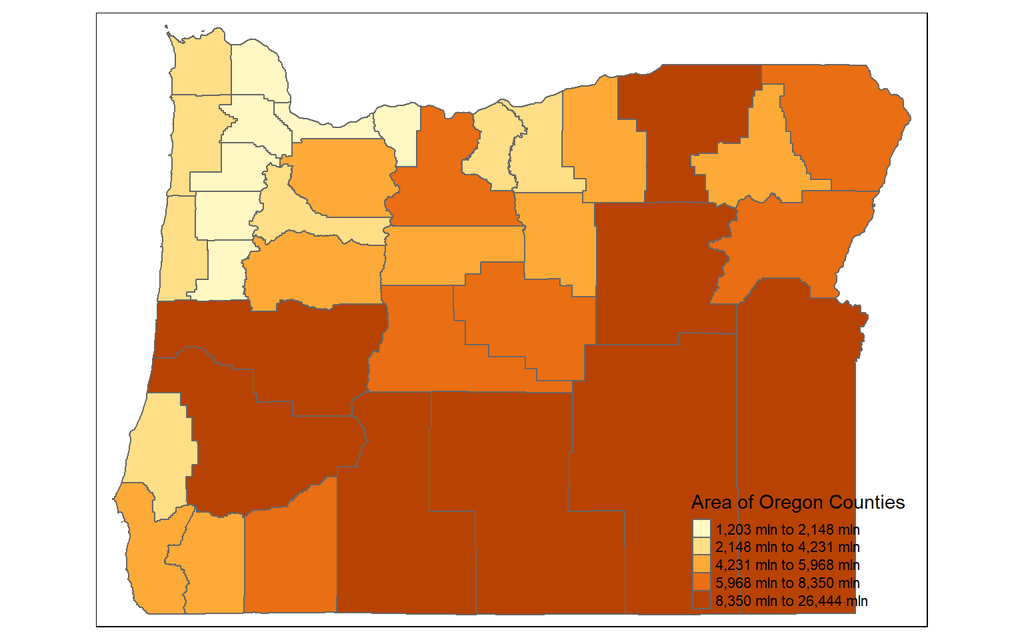

Figure 1: Distribution of Oregon counties.

## Your Turn

Create and explore an interactive map of `my_town` by running

```r
library(mapview)
mapviewOptions(fgb=FALSE)
mapview(my_town, col="red", col.regions = "red") +
  mapview(counties, alpha.regions = .1)
```

## Spatial Data Structures

- Spatial data structures are primarily organized through:
1. GDAL [link here](https://gdal.org/): For raster and feature abstraction and processing
2. PROJ [link here](https://proj.org/): For coordinate transformations and projections
3. GEOS [link here](https://libgeos.org/): For spatial operations (e.g., calculating buffers or centroids) on data with a projected coordinate reference system (CRS)
- We explore these core libraries throughout the workshop

## Types of Spatial Data

- Vector data are comprised of points, lines, and polygons that represent discrete spatial entities (e.g., river, wtaershed, stream gauge)
- Raster data divide space into small rectangles (pixels) that represent spatially continuous phenomena like elevation or precipitation

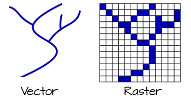

Figure 2: Vector and raster data.

## Vector Data Model

- Vector data are described using simple features
- Simple features is a standard way to specify how two-dimensional geometries are represented, stored in and retrieved from databases, and which geometric operations can be performed
- Provides framework for extending spatial `POINTS` to `LINES` and `POLYGONS`

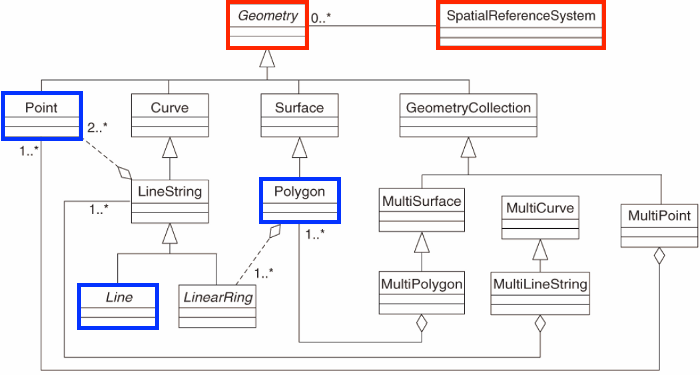

Figure 3: The simple features data model.

## The `sf` package

- We use the `sf` package to work with spatial vector data in **R**
- Learn more about `sf` at their website r-spatial.github.io/sf and/or by running

```r
vignette(package = "sf") # see which vignettes are available
vignette("sf1")          # open the introduction vignette
```

## `POINT`s

- Points in `sf` are composed of coordinate pairs and a coordinate reference system
- Points have no length or area

```r
# create sf object as point
pt1 <- st_point(c(1,3))
pt2 <- st_point(c(2,1))
pt3 <- st_point(c(3,2))
sf_point <- st_sfc(pt1, pt2, pt3)
```

```r
ggplot(sf_point) +
  geom_sf(color = "red") +
  labs(x = "X", y = "Y")
```

## `POINT`s

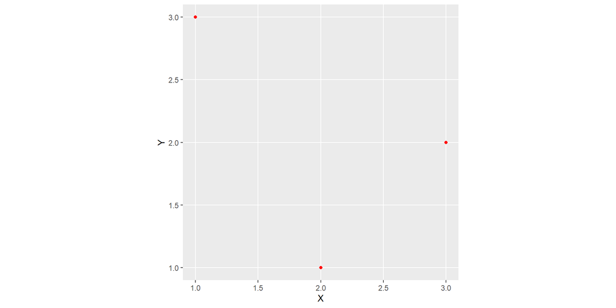

Figure 4: sf `POINT`

## `LINESTRING`s

- An ordered sequence of two or more `POINT`s
- Points in a line are called verticies (or nodes)
- Linestrings have length but no area

```r
# create sf object as linestring
line1 <- sf::st_linestring(rbind(pt1, pt2))
line2 <- sf::st_linestring(rbind(pt2, pt3))
sf_linestring <- st_sfc(line1, line2)
```

```r
ggplot(sf_linestring) +
  geom_sf() +
  labs(x = "X", y = "Y")
```

## `LINESTRING`s

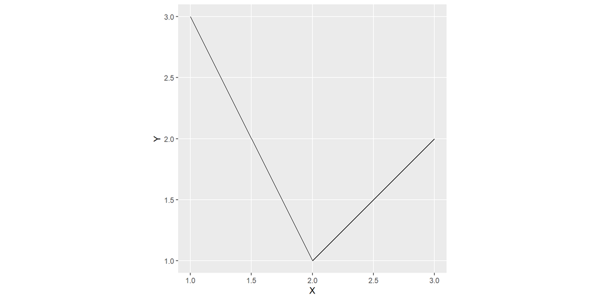

Figure 5: sf `LINESTRING`

## `POLYGON`s

- Four or more points with the same starting and ending point
- Has length and area

```r
pt4 <- pt1
poly1 <- st_polygon(list(rbind(pt1, pt2, pt3, pt4)))
sf_polygon <- st_sfc(poly1)

# dimension
sf::st_dimension(sf_polygon)
```

```
[1] 2
```

```r
ggplot(sf_polygon) +
  geom_sf(fill = "grey")
```

## `POLYGON`s

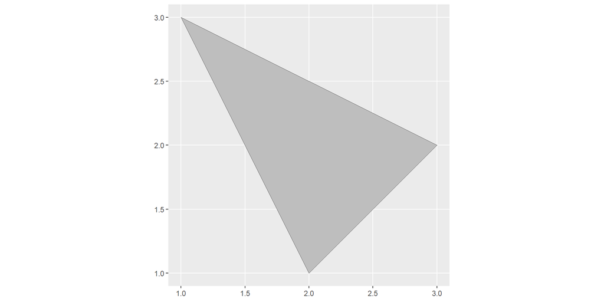

Figure 6: sf `POLYGON`

## Putting Them All Together

```r
ggplot() +
  geom_sf(data = sf_point, color = "red") +
  geom_sf(data = sf_linestring) +
  geom_sf(data = sf_polygon, fill = "grey")
```

## Putting Them All Together

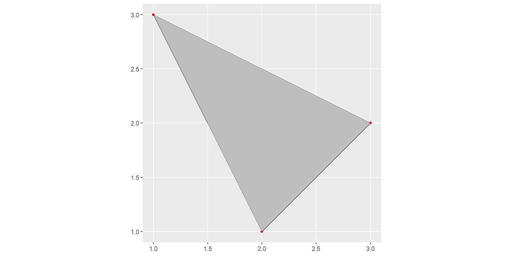

Figure 7: sf `POINT`, `LINESTRING`, and `POLYGON` overlain

## Spatial Data Frames

- `sf` objects combine `data.frame` attributes with `POINT`, `LINESTRING`, and `POLYGON` building blocks (these are the `geometry`)
- Also characterize dimensionality, bounding box, coordinate reference system, attribute headers

```r
library(spData)
data("us_states")
print(us_states)
```

## Spatial Data Frames

```
Simple feature collection with 49 features and 6 fields
Geometry type: MULTIPOLYGON
Dimension:     XY
Bounding box:  xmin: -124.7042 ymin: 24.55868 xmax: -66.9824 ymax: 49.38436
Geodetic CRS:  NAD83
First 10 features:
   GEOID        NAME   REGION             AREA total_pop_10 total_pop_15
1     01     Alabama    South 133709.27 [km^2]      4712651      4830620
2     04     Arizona     West 295281.25 [km^2]      6246816      6641928
3     08    Colorado     West 269573.06 [km^2]      4887061      5278906
4     09 Connecticut Norteast  12976.59 [km^2]      3545837      3593222
5     12     Florida    South 151052.01 [km^2]     18511620     19645772
6     13     Georgia    South 152725.21 [km^2]      9468815     10006693
7     16       Idaho     West 216512.66 [km^2]      1526797      1616547
8     18     Indiana  Midwest  93648.40 [km^2]      6417398      6568645
9     20      Kansas  Midwest 213037.08 [km^2]      2809329      2892987
10    22   Louisiana    South 122345.76 [km^2]      4429940      4625253
                         geometry
1  MULTIPOLYGON (((-88.20006 3...
2  MULTIPOLYGON (((-114.7196 3...
3  MULTIPOLYGON (((-109.0501 4...
4  MULTIPOLYGON (((-73.48731 4...
5  MULTIPOLYGON (((-81.81169 2...
6  MULTIPOLYGON (((-85.60516 3...
7  MULTIPOLYGON (((-116.916 45...
8  MULTIPOLYGON (((-87.52404 4...
9  MULTIPOLYGON (((-102.0517 4...
10 MULTIPOLYGON (((-92.01783 2...
```

## Spatial Data Frames

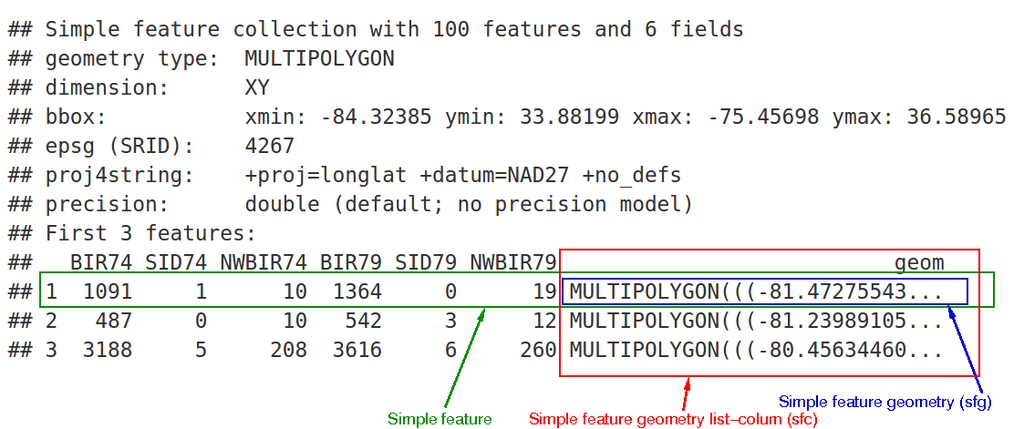

Figure 8: The simple features data structure.

## Your Turn

So far we have explored plotting using `ggplot()`, but you can also use `sf`’s base plotting via `plot()`. Read more about plotting in `sf` by running `?plot.sf` and then make an appropriate plot of the `us_states` data.

Spatial Data Workshop